# Lab 8

```python
import pandas as pd
import numpy as np
from sklearn.model_selection import cross_val_score
from sklearn.discriminant_analysis import LinearDiscriminantAnalysis, QuadraticDiscriminantAnalysis
from sklearn.svm import SVC
from sklearn.neighbors import KNeighborsClassifier
from sklearn.tree import DecisionTreeClassifier, export_text
from sklearn.linear_model import LogisticRegression
from sklearn.pipeline import Pipeline
from sklearn.preprocessing import StandardScaler
from sklearn.impute import SimpleImputer
from sklearn.model_selection import GridSearchCV
from sklearn.metrics import confusion_matrix
from plotnine import *
```

```python
df = pd.read_csv('https://www.dropbox.com/s/s2a1uoiegitupjc/cannabis_full.csv?raw=1')
```

PArt 1: Binary Classification

```python
df_binary = df[df['Type'].isin(['sativa', 'indica'])].copy()
X_binary = df_binary.drop(['Strain', 'Type', 'Rating', 'Effects', 'Flavor'], axis=1)
y_binary = df_binary['Type']
```

```
LDA Cross-validated Accuracy: 0.8446
```

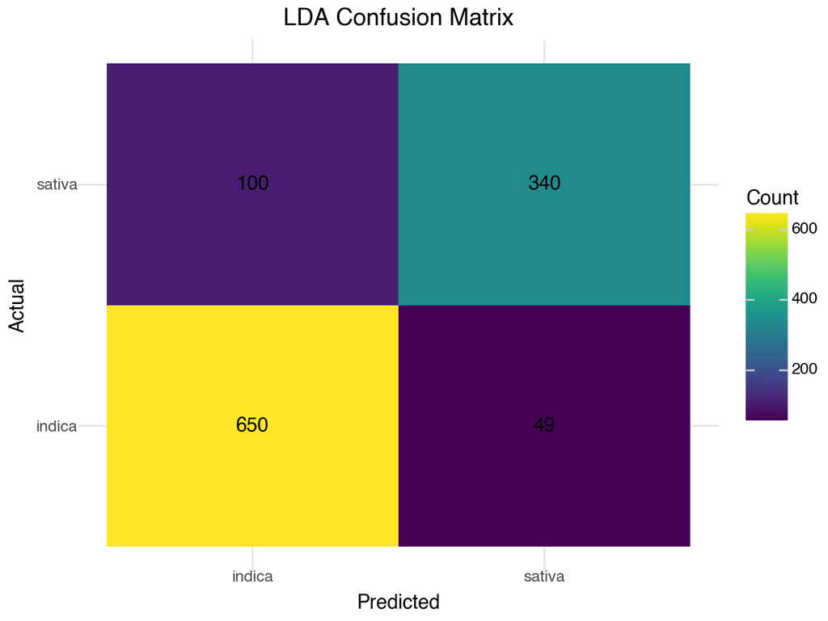

```python
lda_pipeline = Pipeline([
    ('imputer', SimpleImputer(strategy='mean')),
    ('scaler', StandardScaler()),
    ('lda', LinearDiscriminantAnalysis())
])

lda_cv_scores = cross_val_score(lda_pipeline, X_binary, y_binary, cv=5, scoring='accuracy')
print(f"LDA Cross-validated Accuracy: {lda_cv_scores.mean():.4f}")

lda_pipeline.fit(X_binary, y_binary)
y_pred_lda = lda_pipeline.predict(X_binary)
cm = confusion_matrix(y_binary, y_pred_lda)
cm_df = pd.DataFrame(cm, index=['indica', 'sativa'], columns=['indica', 'sativa'])
cm_df = cm_df.reset_index().melt(id_vars='index')
cm_df.columns = ['Actual', 'Predicted', 'Count']
(ggplot(cm_df, aes(x='Predicted', y='Actual', fill='Count')) +
 geom_tile() +
 geom_text(aes(label='Count')) +
 labs(title='LDA Confusion Matrix') +
 theme_minimal())
```

QDA

```
QDA Cross-validated Accuracy: 0.4750
```

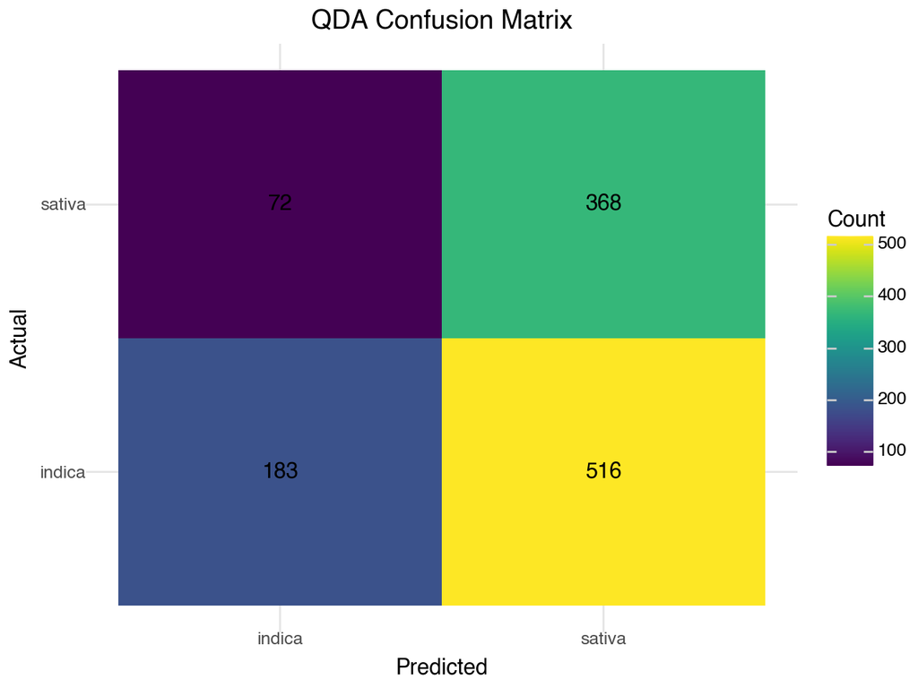

```python
qda_pipeline = Pipeline([
    ('imputer', SimpleImputer(strategy='mean')),
    ('scaler', StandardScaler()),
    ('qda', QuadraticDiscriminantAnalysis())
])

qda_cv_scores = cross_val_score(qda_pipeline, X_binary, y_binary, cv=5, scoring='accuracy')
print(f"QDA Cross-validated Accuracy: {qda_cv_scores.mean():.4f}")

qda_pipeline.fit(X_binary, y_binary)
y_pred_qda = qda_pipeline.predict(X_binary)
cm = confusion_matrix(y_binary, y_pred_qda)
cm_df = pd.DataFrame(cm, index=['indica', 'sativa'], columns=['indica', 'sativa'])
cm_df = cm_df.reset_index().melt(id_vars='index')
cm_df.columns = ['Actual', 'Predicted', 'Count']
(ggplot(cm_df, aes(x='Predicted', y='Actual', fill='Count')) +
 geom_tile() +
 geom_text(aes(label='Count')) +
 labs(title='QDA Confusion Matrix') +
 theme_minimal())
```

SVC

```
Best SVC parameters: {'svc__C': 0.1, 'svc__kernel': 'linear'}
SVC Cross-validated Accuracy: 0.8455
```

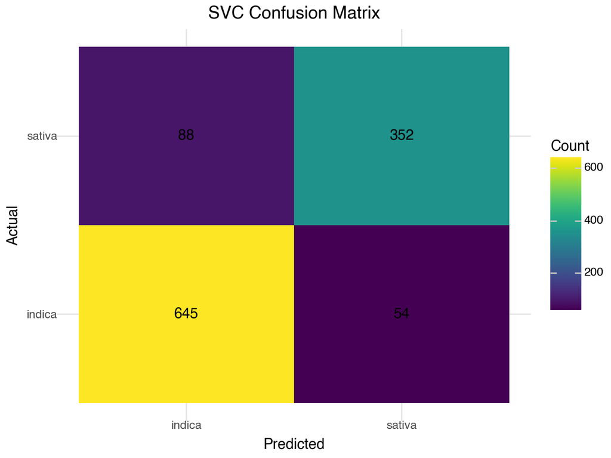

```python
svc_pipeline = Pipeline([
    ('imputer', SimpleImputer(strategy='mean')),
    ('scaler', StandardScaler()),
    ('svc', SVC())
])

svc_param_grid = {
    'svc__C': [0.1, 1, 10],
    'svc__kernel': ['linear', 'rbf']
}

svc_grid = GridSearchCV(svc_pipeline, svc_param_grid, cv=5, scoring='accuracy')
svc_grid.fit(X_binary, y_binary)

print(f"Best SVC parameters: {svc_grid.best_params_}")
print(f"SVC Cross-validated Accuracy: {svc_grid.best_score_:.4f}")

y_pred_svc = svc_grid.best_estimator_.predict(X_binary)
cm = confusion_matrix(y_binary, y_pred_svc)
cm_df = pd.DataFrame(cm, index=['indica', 'sativa'], columns=['indica', 'sativa'])
cm_df = cm_df.reset_index().melt(id_vars='index')
cm_df.columns = ['Actual', 'Predicted', 'Count']
(ggplot(cm_df, aes(x='Predicted', y='Actual', fill='Count')) +
 geom_tile() +
 geom_text(aes(label='Count')) +
 labs(title='SVC Confusion Matrix') +
 theme_minimal())
```

SVM

```
Best SVM parameters: {'svm__C': 10, 'svm__degree': 3}
SVM Cross-validated Accuracy: 0.8200
```

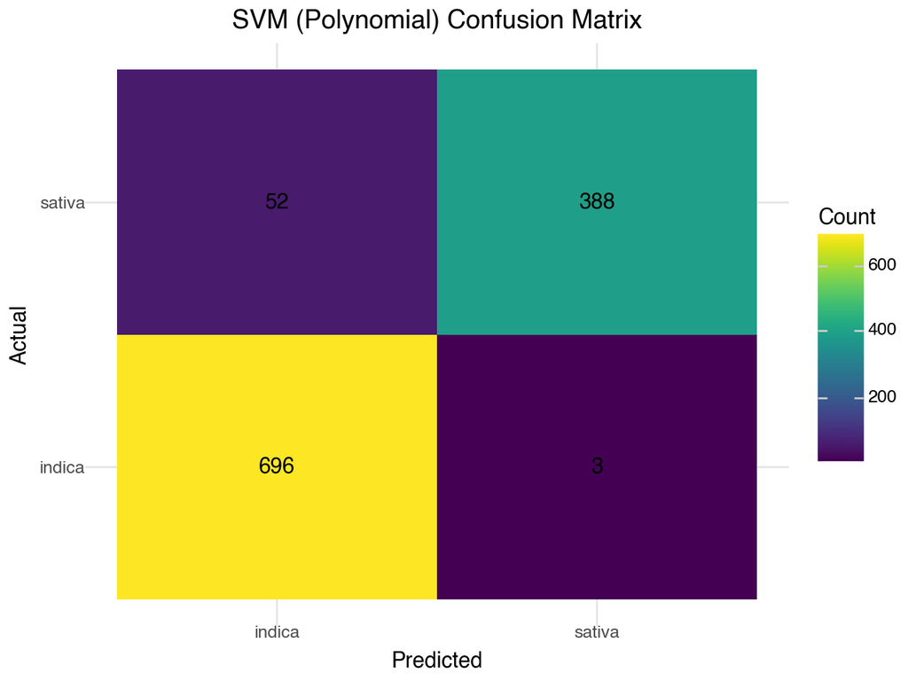

```python
svm_pipeline = Pipeline([
    ('imputer', SimpleImputer(strategy='mean')),
    ('scaler', StandardScaler()),
    ('svm', SVC(kernel='poly'))
])

svm_param_grid = {
    'svm__C': [0.1, 1, 10],
    'svm__degree': [2, 3, 4]
}

svm_grid = GridSearchCV(svm_pipeline, svm_param_grid, cv=5, scoring='accuracy')
svm_grid.fit(X_binary, y_binary)

print(f"Best SVM parameters: {svm_grid.best_params_}")
print(f"SVM Cross-validated Accuracy: {svm_grid.best_score_:.4f}")

y_pred_svm = svm_grid.best_estimator_.predict(X_binary)
cm = confusion_matrix(y_binary, y_pred_svm)
cm_df = pd.DataFrame(cm, index=['indica', 'sativa'], columns=['indica', 'sativa'])
cm_df = cm_df.reset_index().melt(id_vars='index')
cm_df.columns = ['Actual', 'Predicted', 'Count']
(ggplot(cm_df, aes(x='Predicted', y='Actual', fill='Count')) +
 geom_tile() +
 geom_text(aes(label='Count')) +
 labs(title='SVM (Polynomial) Confusion Matrix') +
 theme_minimal())
```

Part Two: Natural Multiclass

```python
X_full = df.drop(['Strain', 'Type', 'Rating', 'Effects', 'Flavor'], axis=1)
y_full = df['Type']
```

Question 1 Decison Tree

```python
tree_pipeline = Pipeline([
    ('tree', DecisionTreeClassifier(random_state=42))
])

tree_param_grid = {
    'tree__max_depth': [3, 5, 7, 10],
    'tree__min_samples_split': [2, 5, 10]
}

tree_grid = GridSearchCV(tree_pipeline, tree_param_grid, cv=5, scoring='accuracy')
tree_grid.fit(X_full, y_full)

print(f"Best Decision Tree parameters: {tree_grid.best_params_}")
print(f"Decision Tree Cross-validated Accuracy: {tree_grid.best_score_:.4f}")

tree_rules = export_text(tree_grid.best_estimator_.named_steps['tree'],
                         feature_names=list(X_full.columns))
print("\nDecision Tree Rules:")
print(tree_rules)
```

```
Best Decision Tree parameters: {'tree__max_depth': 3, 'tree__min_samples_split': 2}
Decision Tree Cross-validated Accuracy: 0.6172

Decision Tree Rules:
|--- Sleepy <= 0.50
|   |--- Energetic <= 0.50
|   |   |--- Pineapple <= nan
|   |   |   |--- class: sativa
|   |   |--- Pineapple >  nan
|   |   |   |--- class: hybrid
|   |--- Energetic >  0.50
|   |   |--- Relaxed <= 0.50
|   |   |   |--- class: sativa
|   |   |--- Relaxed >  0.50
|   |   |   |--- class: hybrid
|--- Sleepy >  0.50
|   |--- Citrus <= 0.50
|   |   |--- Uplifted <= 0.50
|   |   |   |--- class: indica
|   |   |--- Uplifted >  0.50
|   |   |   |--- class: indica
|   |--- Citrus >  0.50
|   |   |--- Sweet <= 0.50
|   |   |   |--- class: indica
|   |   |--- Sweet >  0.50
|   |   |   |--- class: hybrid
```

Sleepy is the most influencal varialbe when predicitng class.

Question 2 LDA

```
LDA Multiclass Cross-validated Accuracy: 0.6287
```

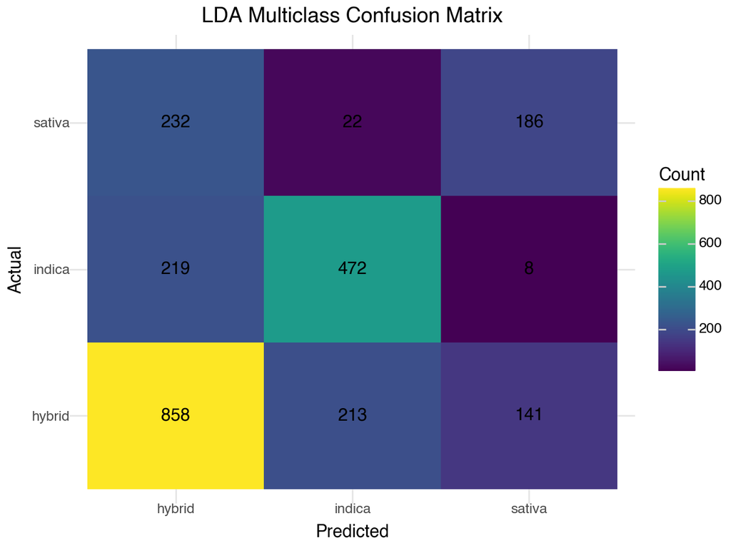

```python
lda_multi_pipeline = Pipeline([
    ('imputer', SimpleImputer(strategy='mean')),
    ('scaler', StandardScaler()),
    ('lda', LinearDiscriminantAnalysis())
])

lda_multi_cv = cross_val_score(lda_multi_pipeline, X_full, y_full, cv=5, scoring='accuracy')
print(f"LDA Multiclass Cross-validated Accuracy: {lda_multi_cv.mean():.4f}")

lda_multi_pipeline.fit(X_full, y_full)
y_pred_lda_multi = lda_multi_pipeline.predict(X_full)
cm = confusion_matrix(y_full, y_pred_lda_multi)
cm_df = pd.DataFrame(cm, index=['hybrid', 'indica', 'sativa'], columns=['hybrid', 'indica', 'sativa'])
cm_df = cm_df.reset_index().melt(id_vars='index')
cm_df.columns = ['Actual', 'Predicted', 'Count']
(ggplot(cm_df, aes(x='Predicted', y='Actual', fill='Count')) +
 geom_tile() +
 geom_text(aes(label='Count')) +
 labs(title='LDA Multiclass Confusion Matrix') +
 theme_minimal())
```

QDA

```
QDA Multiclass Cross-validated Accuracy: 0.2667
```

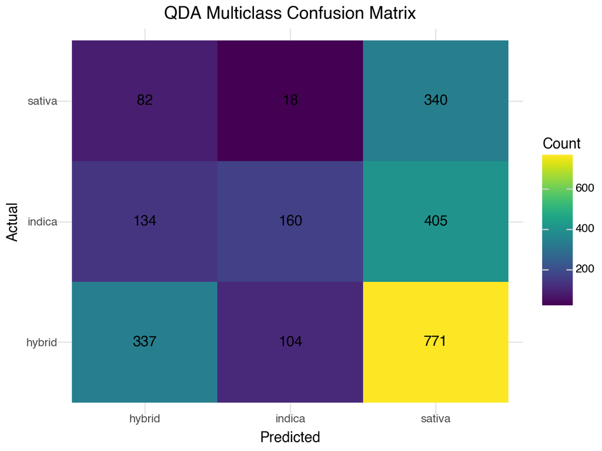

```python
qda_multi_pipeline = Pipeline([
    ('imputer', SimpleImputer(strategy='mean')),
    ('scaler', StandardScaler()),
    ('qda', QuadraticDiscriminantAnalysis())
])

qda_multi_cv = cross_val_score(qda_multi_pipeline, X_full, y_full, cv=5, scoring='accuracy')
print(f"QDA Multiclass Cross-validated Accuracy: {qda_multi_cv.mean():.4f}")

qda_multi_pipeline.fit(X_full, y_full)
y_pred_qda_multi = qda_multi_pipeline.predict(X_full)
cm = confusion_matrix(y_full, y_pred_qda_multi)
cm_df = pd.DataFrame(cm, index=['hybrid', 'indica', 'sativa'], columns=['hybrid', 'indica', 'sativa'])
cm_df = cm_df.reset_index().melt(id_vars='index')
cm_df.columns = ['Actual', 'Predicted', 'Count']
(ggplot(cm_df, aes(x='Predicted', y='Actual', fill='Count')) +
 geom_tile() +
 geom_text(aes(label='Count')) +
 labs(title='QDA Multiclass Confusion Matrix') +
 theme_minimal())
```

KNN

```
Best KNN parameters: {'knn__n_neighbors': 11}
KNN Cross-validated Accuracy: 0.5504
```

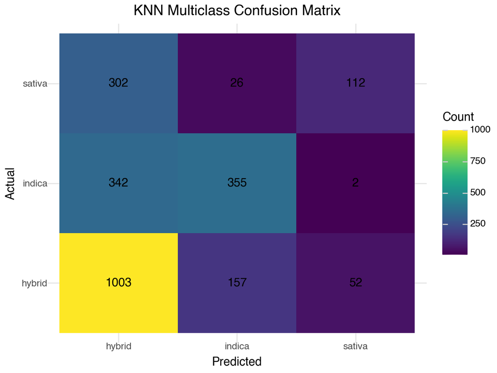

```python
knn_pipeline = Pipeline([
    ('imputer', SimpleImputer(strategy='mean')),
    ('scaler', StandardScaler()),
    ('knn', KNeighborsClassifier())
])

knn_param_grid = {
    'knn__n_neighbors': [3, 5, 7, 9, 11]
}

knn_grid = GridSearchCV(knn_pipeline, knn_param_grid, cv=5, scoring='accuracy')
knn_grid.fit(X_full, y_full)

print(f"Best KNN parameters: {knn_grid.best_params_}")
print(f"KNN Cross-validated Accuracy: {knn_grid.best_score_:.4f}")

y_pred_knn = knn_grid.best_estimator_.predict(X_full)
cm = confusion_matrix(y_full, y_pred_knn)
cm_df = pd.DataFrame(cm, index=['hybrid', 'indica', 'sativa'], columns=['hybrid', 'indica', 'sativa'])
cm_df = cm_df.reset_index().melt(id_vars='index')
cm_df.columns = ['Actual', 'Predicted', 'Count']
(ggplot(cm_df, aes(x='Predicted', y='Actual', fill='Count')) +
 geom_tile() +
 geom_text(aes(label='Count')) +
 labs(title='KNN Multiclass Confusion Matrix') +
 theme_minimal())
```

Q3 Comparsion My cross validated accuracy was better in part 1. This is probably because we used a smaller sized data set and so there was less variables to consdier.

Part Three: Multiclass from Binary

Question 1

SVC OvR - Indica vs Not Indica

```
SVC Indica vs Not: 0.7788
```

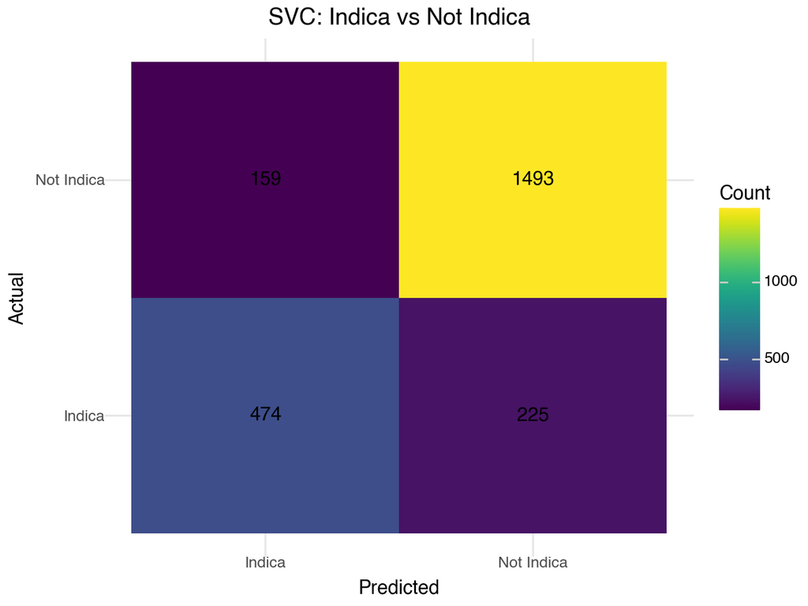

```python
y_indica = (y_full == 'indica').astype(int)
svc_indica_pipeline = Pipeline([
    ('imputer', SimpleImputer(strategy='mean')),
    ('scaler', StandardScaler()),
    ('svc', SVC())
])
svc_indica_cv = cross_val_score(svc_indica_pipeline, X_full, y_indica, cv=5, scoring='accuracy')
print(f"SVC Indica vs Not: {svc_indica_cv.mean():.4f}")

svc_indica_pipeline.fit(X_full, y_indica)
y_pred = svc_indica_pipeline.predict(X_full)
cm = confusion_matrix(y_indica, y_pred)
cm_df = pd.DataFrame(cm, index=['Not Indica', 'Indica'], columns=['Not Indica', 'Indica'])
cm_df = cm_df.reset_index().melt(id_vars='index')
cm_df.columns = ['Actual', 'Predicted', 'Count']
(ggplot(cm_df, aes(x='Predicted', y='Actual', fill='Count')) +
 geom_tile() +
 geom_text(aes(label='Count')) +
 labs(title='SVC: Indica vs Not Indica') +
 theme_minimal())
```

SVC OvR - Sativa vs Not Sativa

```
SVC Sativa vs Not: 0.8137
```

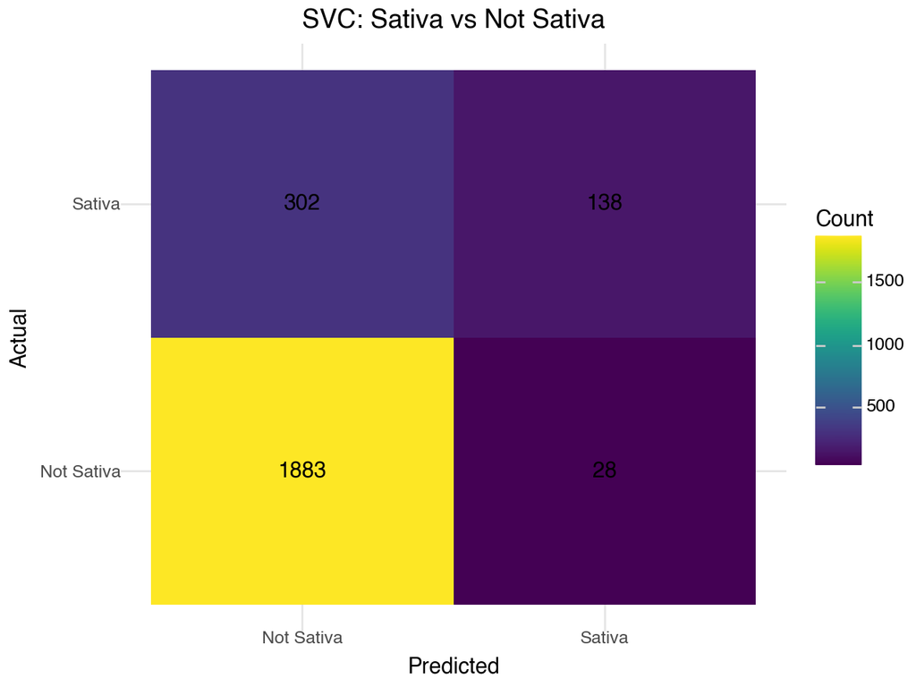

```python
y_sativa = (y_full == 'sativa').astype(int)
svc_sativa_pipeline = Pipeline([
    ('imputer', SimpleImputer(strategy='mean')),
    ('scaler', StandardScaler()),
    ('svc', SVC())
])
svc_sativa_cv = cross_val_score(svc_sativa_pipeline, X_full, y_sativa, cv=5, scoring='accuracy')
print(f"SVC Sativa vs Not: {svc_sativa_cv.mean():.4f}")

svc_sativa_pipeline.fit(X_full, y_sativa)
y_pred = svc_sativa_pipeline.predict(X_full)
cm = confusion_matrix(y_sativa, y_pred)
cm_df = pd.DataFrame(cm, index=['Not Sativa', 'Sativa'], columns=['Not Sativa', 'Sativa'])
cm_df = cm_df.reset_index().melt(id_vars='index')
cm_df.columns = ['Actual', 'Predicted', 'Count']
(ggplot(cm_df, aes(x='Predicted', y='Actual', fill='Count')) +
 geom_tile() +
 geom_text(aes(label='Count')) +
 labs(title='SVC: Sativa vs Not Sativa') +
 theme_minimal())
```

SVC OvR - Hybrid vs Not Hybrid

```
SVC Hybrid vs Not: 0.6104
```

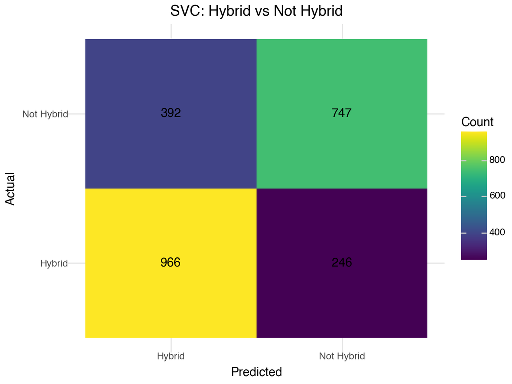

```python
y_hybrid = (y_full == 'hybrid').astype(int)
svc_hybrid_pipeline = Pipeline([
    ('imputer', SimpleImputer(strategy='mean')),
    ('scaler', StandardScaler()),
    ('svc', SVC())
])
svc_hybrid_cv = cross_val_score(svc_hybrid_pipeline, X_full, y_hybrid, cv=5, scoring='accuracy')
print(f"SVC Hybrid vs Not: {svc_hybrid_cv.mean():.4f}")

svc_hybrid_pipeline.fit(X_full, y_hybrid)
y_pred = svc_hybrid_pipeline.predict(X_full)
cm = confusion_matrix(y_hybrid, y_pred)
cm_df = pd.DataFrame(cm, index=['Not Hybrid', 'Hybrid'], columns=['Not Hybrid', 'Hybrid'])
cm_df = cm_df.reset_index().melt(id_vars='index')
cm_df.columns = ['Actual', 'Predicted', 'Count']
(ggplot(cm_df, aes(x='Predicted', y='Actual', fill='Count')) +
 geom_tile() +
 geom_text(aes(label='Count')) +
 labs(title='SVC: Hybrid vs Not Hybrid') +
 theme_minimal())
```

Logistic Regression OvR - Indica vs Not Indica

```
Logistic Regression Indica vs Not: 0.7869
```

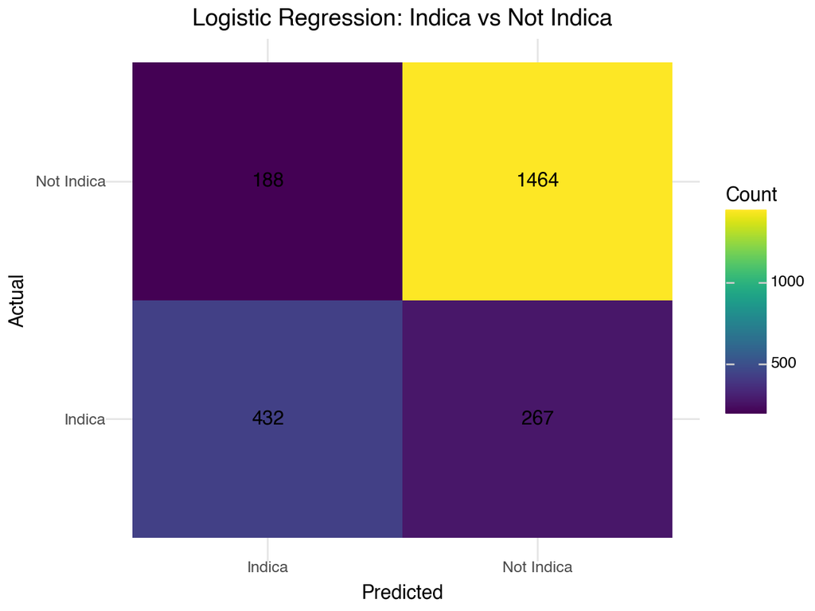

```python
lr_indica_pipeline = Pipeline([
    ('imputer', SimpleImputer(strategy='mean')),
    ('scaler', StandardScaler()),
    ('lr', LogisticRegression(max_iter=1000))
])
lr_indica_cv = cross_val_score(lr_indica_pipeline, X_full, y_indica, cv=5, scoring='accuracy')
print(f"Logistic Regression Indica vs Not: {lr_indica_cv.mean():.4f}")

lr_indica_pipeline.fit(X_full, y_indica)
y_pred = lr_indica_pipeline.predict(X_full)
cm = confusion_matrix(y_indica, y_pred)
cm_df = pd.DataFrame(cm, index=['Not Indica', 'Indica'], columns=['Not Indica', 'Indica'])
cm_df = cm_df.reset_index().melt(id_vars='index')
cm_df.columns = ['Actual', 'Predicted', 'Count']
(ggplot(cm_df, aes(x='Predicted', y='Actual', fill='Count')) +
 geom_tile() +
 geom_text(aes(label='Count')) +
 labs(title='Logistic Regression: Indica vs Not Indica') +
 theme_minimal())
```

Logistic Regression OvR - Sativa vs Not Sativa

```
Logistic Regression Sativa vs Not: 0.8252
```

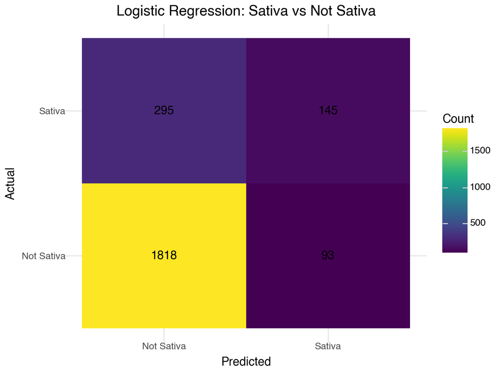

```python
lr_sativa_pipeline = Pipeline([
    ('imputer', SimpleImputer(strategy='mean')),
    ('scaler', StandardScaler()),
    ('lr', LogisticRegression(max_iter=1000))
])
lr_sativa_cv = cross_val_score(lr_sativa_pipeline, X_full, y_sativa, cv=5, scoring='accuracy')
print(f"Logistic Regression Sativa vs Not: {lr_sativa_cv.mean():.4f}")

lr_sativa_pipeline.fit(X_full, y_sativa)
y_pred = lr_sativa_pipeline.predict(X_full)
cm = confusion_matrix(y_sativa, y_pred)
cm_df = pd.DataFrame(cm, index=['Not Sativa', 'Sativa'], columns=['Not Sativa', 'Sativa'])
cm_df = cm_df.reset_index().melt(id_vars='index')
cm_df.columns = ['Actual', 'Predicted', 'Count']
(ggplot(cm_df, aes(x='Predicted', y='Actual', fill='Count')) +
 geom_tile() +
 geom_text(aes(label='Count')) +
 labs(title='Logistic Regression: Sativa vs Not Sativa') +
 theme_minimal())
```

Logistic Regression OvR - Hybrid vs Not Hybrid

```
Logistic Regression Hybrid vs Not: 0.6121
```

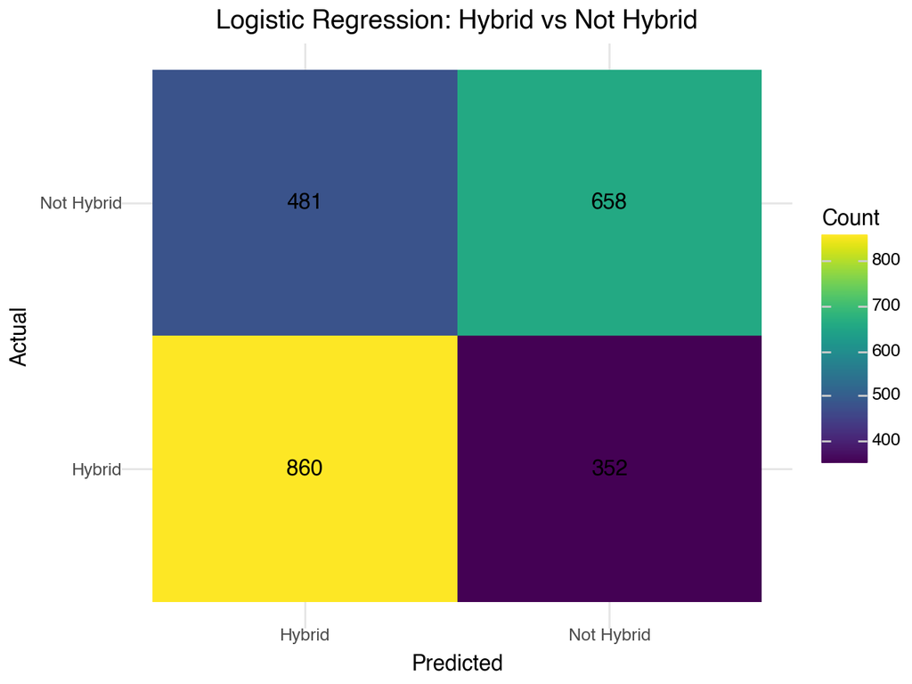

```python
lr_hybrid_pipeline = Pipeline([
    ('imputer', SimpleImputer(strategy='mean')),
    ('scaler', StandardScaler()),
    ('lr', LogisticRegression(max_iter=1000))
])
lr_hybrid_cv = cross_val_score(lr_hybrid_pipeline, X_full, y_hybrid, cv=5, scoring='accuracy')
print(f"Logistic Regression Hybrid vs Not: {lr_hybrid_cv.mean():.4f}")

lr_hybrid_pipeline.fit(X_full, y_hybrid)
y_pred = lr_hybrid_pipeline.predict(X_full)
cm = confusion_matrix(y_hybrid, y_pred)
cm_df = pd.DataFrame(cm, index=['Not Hybrid', 'Hybrid'], columns=['Not Hybrid', 'Hybrid'])
cm_df = cm_df.reset_index().melt(id_vars='index')
cm_df.columns = ['Actual', 'Predicted', 'Count']
(ggplot(cm_df, aes(x='Predicted', y='Actual', fill='Count')) +
 geom_tile() +
 geom_text(aes(label='Count')) +
 labs(title='Logistic Regression: Hybrid vs Not Hybrid') +
 theme_minimal())
```

Question 2 Which of the six models did the best job distinguishing the target category from the rest? Which did the worst? Does this make intuitive sense?

The Logstic regression OvR - Sativa vs not Sativa model has the highest level of accuracy. The worst model was SVC OvR - Hybrid vs Not Hybrid. Yes this makes the most sense as for this type of problem, a LR is already a better choice and on top of that predicting sativa vs not sativa (two opposites) is much easier than predicting hybrid vs not hybrid, as non hyrbids of features of hybrids.

Question 3 OvO Models

SVC OvO - Indica vs Sativa

```
SVC Indica vs Sativa: 0.8209
```

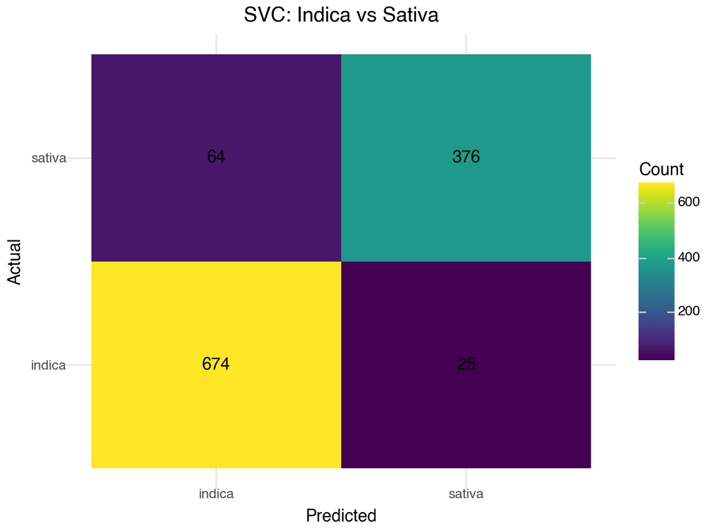

```python
df_indica_sativa = df[df['Type'].isin(['indica', 'sativa'])].copy()
X_indica_sativa = df_indica_sativa.drop(['Strain', 'Type', 'Rating', 'Effects', 'Flavor'], axis=1)
y_indica_sativa = df_indica_sativa['Type']

svc_indica_sativa_pipeline = Pipeline([
    ('imputer', SimpleImputer(strategy='mean')),
    ('scaler', StandardScaler()),
    ('svc', SVC())
])
svc_indica_sativa_cv = cross_val_score(svc_indica_sativa_pipeline, X_indica_sativa, y_indica_sativa, cv=5, scoring='accuracy')
print(f"SVC Indica vs Sativa: {svc_indica_sativa_cv.mean():.4f}")

svc_indica_sativa_pipeline.fit(X_indica_sativa, y_indica_sativa)
y_pred = svc_indica_sativa_pipeline.predict(X_indica_sativa)
cm = confusion_matrix(y_indica_sativa, y_pred)
cm_df = pd.DataFrame(cm, index=['indica', 'sativa'], columns=['indica', 'sativa'])
cm_df = cm_df.reset_index().melt(id_vars='index')
cm_df.columns = ['Actual', 'Predicted', 'Count']
(ggplot(cm_df, aes(x='Predicted', y='Actual', fill='Count')) +
 geom_tile() +
 geom_text(aes(label='Count')) +
 labs(title='SVC: Indica vs Sativa') +
 theme_minimal())
```

SVC OvO - Indica vs Hybrid

```
SVC Indica vs Hybrid: 0.7300
```

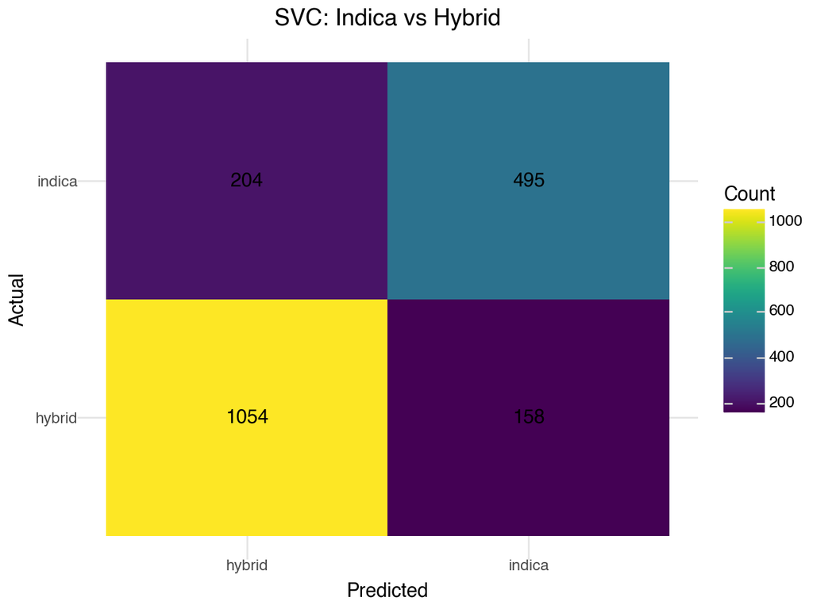

```python
df_indica_hybrid = df[df['Type'].isin(['indica', 'hybrid'])].copy()
X_indica_hybrid = df_indica_hybrid.drop(['Strain', 'Type', 'Rating', 'Effects', 'Flavor'], axis=1)
y_indica_hybrid = df_indica_hybrid['Type']

svc_indica_hybrid_pipeline = Pipeline([
    ('imputer', SimpleImputer(strategy='mean')),
    ('scaler', StandardScaler()),
    ('svc', SVC())
])
svc_indica_hybrid_cv = cross_val_score(svc_indica_hybrid_pipeline, X_indica_hybrid, y_indica_hybrid, cv=5, scoring='accuracy')
print(f"SVC Indica vs Hybrid: {svc_indica_hybrid_cv.mean():.4f}")

svc_indica_hybrid_pipeline.fit(X_indica_hybrid, y_indica_hybrid)
y_pred = svc_indica_hybrid_pipeline.predict(X_indica_hybrid)
cm = confusion_matrix(y_indica_hybrid, y_pred)
cm_df = pd.DataFrame(cm, index=['hybrid', 'indica'], columns=['hybrid', 'indica'])
cm_df = cm_df.reset_index().melt(id_vars='index')
cm_df.columns = ['Actual', 'Predicted', 'Count']
(ggplot(cm_df, aes(x='Predicted', y='Actual', fill='Count')) +
 geom_tile() +
 geom_text(aes(label='Count')) +
 labs(title='SVC: Indica vs Hybrid') +
 theme_minimal())
```

SVC OvO - Hybrid vs Sativa

```
SVC Hybrid vs Sativa: 0.7330
```

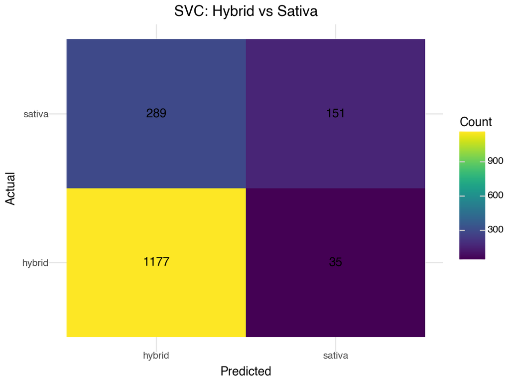

```python
df_hybrid_sativa = df[df['Type'].isin(['hybrid', 'sativa'])].copy()
X_hybrid_sativa = df_hybrid_sativa.drop(['Strain', 'Type', 'Rating', 'Effects', 'Flavor'], axis=1)
y_hybrid_sativa = df_hybrid_sativa['Type']

svc_hybrid_sativa_pipeline = Pipeline([
    ('imputer', SimpleImputer(strategy='mean')),
    ('scaler', StandardScaler()),
    ('svc', SVC())
])
svc_hybrid_sativa_cv = cross_val_score(svc_hybrid_sativa_pipeline, X_hybrid_sativa, y_hybrid_sativa, cv=5, scoring='accuracy')
print(f"SVC Hybrid vs Sativa: {svc_hybrid_sativa_cv.mean():.4f}")

svc_hybrid_sativa_pipeline.fit(X_hybrid_sativa, y_hybrid_sativa)
y_pred = svc_hybrid_sativa_pipeline.predict(X_hybrid_sativa)
cm = confusion_matrix(y_hybrid_sativa, y_pred)
cm_df = pd.DataFrame(cm, index=['hybrid', 'sativa'], columns=['hybrid', 'sativa'])
cm_df = cm_df.reset_index().melt(id_vars='index')
cm_df.columns = ['Actual', 'Predicted', 'Count']
(ggplot(cm_df, aes(x='Predicted', y='Actual', fill='Count')) +
 geom_tile() +
 geom_text(aes(label='Count')) +
 labs(title='SVC: Hybrid vs Sativa') +
 theme_minimal())
```

Logistic Regression OvO - Indica vs Sativa

```
Logistic Regression Indica vs Sativa: 0.8429
```

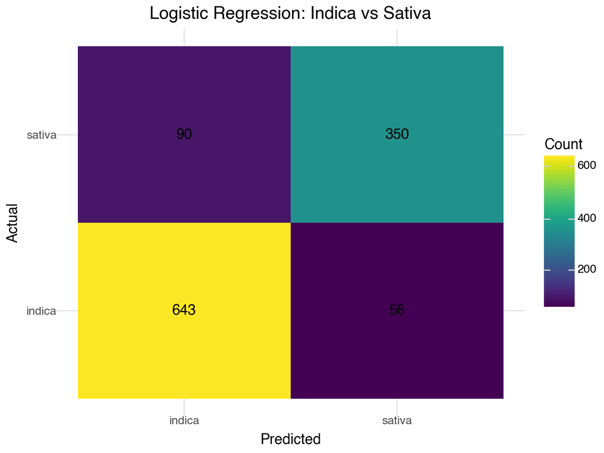

```python
lr_indica_sativa_pipeline = Pipeline([
    ('imputer', SimpleImputer(strategy='mean')),
    ('scaler', StandardScaler()),
    ('lr', LogisticRegression(max_iter=1000))
])
lr_indica_sativa_cv = cross_val_score(lr_indica_sativa_pipeline, X_indica_sativa, y_indica_sativa, cv=5, scoring='accuracy')
print(f"Logistic Regression Indica vs Sativa: {lr_indica_sativa_cv.mean():.4f}")

lr_indica_sativa_pipeline.fit(X_indica_sativa, y_indica_sativa)
y_pred = lr_indica_sativa_pipeline.predict(X_indica_sativa)
cm = confusion_matrix(y_indica_sativa, y_pred)
cm_df = pd.DataFrame(cm, index=['indica', 'sativa'], columns=['indica', 'sativa'])
cm_df = cm_df.reset_index().melt(id_vars='index')
cm_df.columns = ['Actual', 'Predicted', 'Count']
(ggplot(cm_df, aes(x='Predicted', y='Actual', fill='Count')) +
 geom_tile() +
 geom_text(aes(label='Count')) +
 labs(title='Logistic Regression: Indica vs Sativa') +
 theme_minimal())
```

Logistic Regression OvO - Indica vs Hybrid

```
Logistic Regression Indica vs Hybrid: 0.7483
```

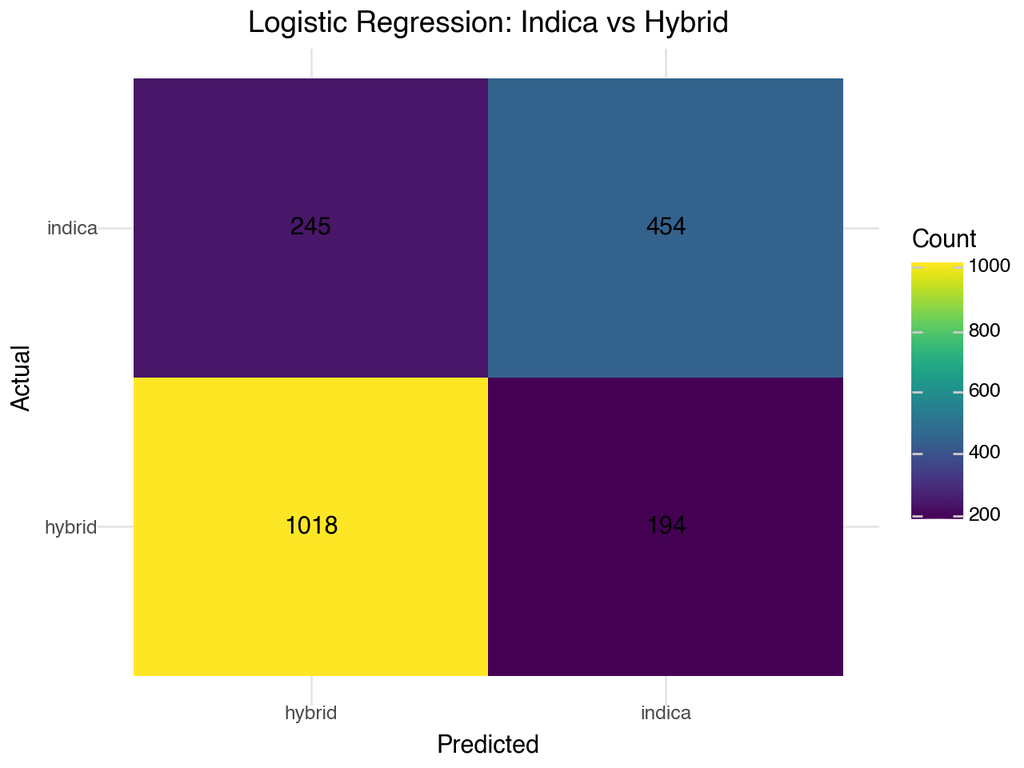

```python
lr_indica_hybrid_pipeline = Pipeline([
    ('imputer', SimpleImputer(strategy='mean')),
    ('scaler', StandardScaler()),
    ('lr', LogisticRegression(max_iter=1000))
])
lr_indica_hybrid_cv = cross_val_score(lr_indica_hybrid_pipeline, X_indica_hybrid, y_indica_hybrid, cv=5, scoring='accuracy')
print(f"Logistic Regression Indica vs Hybrid: {lr_indica_hybrid_cv.mean():.4f}")

lr_indica_hybrid_pipeline.fit(X_indica_hybrid, y_indica_hybrid)
y_pred = lr_indica_hybrid_pipeline.predict(X_indica_hybrid)
cm = confusion_matrix(y_indica_hybrid, y_pred)
cm_df = pd.DataFrame(cm, index=['hybrid', 'indica'], columns=['hybrid', 'indica'])
cm_df = cm_df.reset_index().melt(id_vars='index')
cm_df.columns = ['Actual', 'Predicted', 'Count']
(ggplot(cm_df, aes(x='Predicted', y='Actual', fill='Count')) +
 geom_tile() +
 geom_text(aes(label='Count')) +
 labs(title='Logistic Regression: Indica vs Hybrid') +
 theme_minimal())
```

Logistic Regression OvO - Hybrid vs Sativa

```
Logistic Regression Hybrid vs Sativa: 0.7445
```

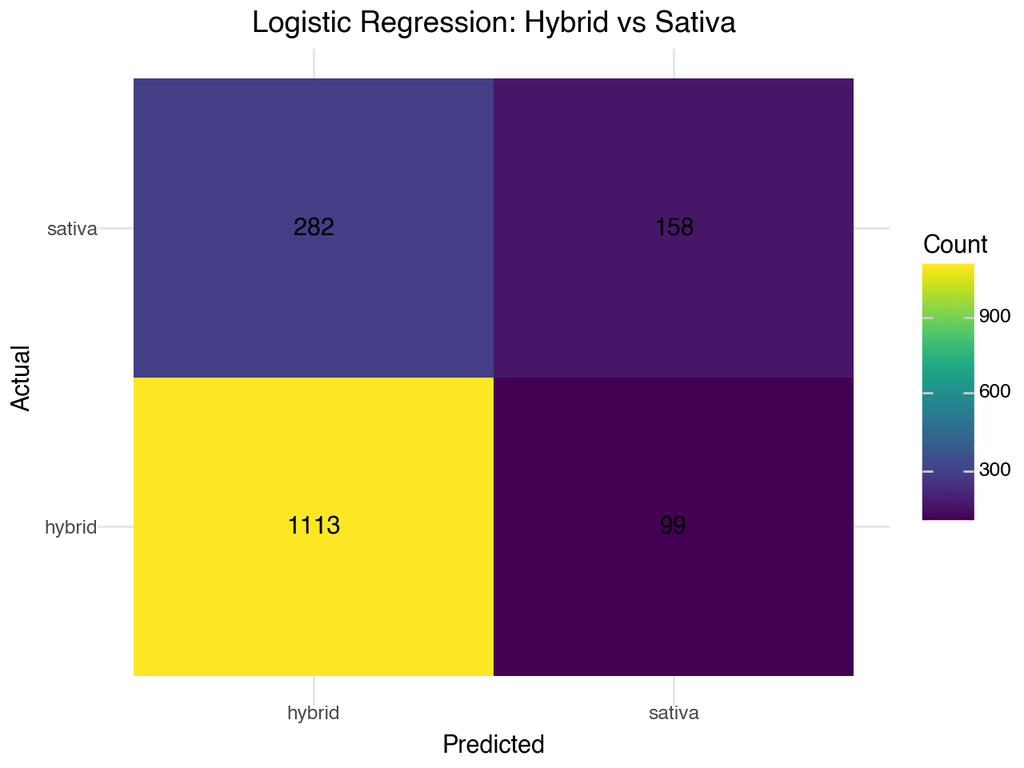

```python
lr_hybrid_sativa_pipeline = Pipeline([
    ('imputer', SimpleImputer(strategy='mean')),
    ('scaler', StandardScaler()),
    ('lr', LogisticRegression(max_iter=1000))
])
lr_hybrid_sativa_cv = cross_val_score(lr_hybrid_sativa_pipeline, X_hybrid_sativa, y_hybrid_sativa, cv=5, scoring='accuracy')
print(f"Logistic Regression Hybrid vs Sativa: {lr_hybrid_sativa_cv.mean():.4f}")

lr_hybrid_sativa_pipeline.fit(X_hybrid_sativa, y_hybrid_sativa)
y_pred = lr_hybrid_sativa_pipeline.predict(X_hybrid_sativa)
cm = confusion_matrix(y_hybrid_sativa, y_pred)
cm_df = pd.DataFrame(cm, index=['hybrid', 'sativa'], columns=['hybrid', 'sativa'])
cm_df = cm_df.reset_index().melt(id_vars='index')
cm_df.columns = ['Actual', 'Predicted', 'Count']
(ggplot(cm_df, aes(x='Predicted', y='Actual', fill='Count')) +
 geom_tile() +
 geom_text(aes(label='Count')) +
 labs(title='Logistic Regression: Hybrid vs Sativa') +
 theme_minimal())
```

Q4: Which of the six models did the best job distinguishing at differentiating the two groups? Which did the worst? Does this make intuitive sense?

The best OvO model was logstic regression indica vs sativa. The worst OvO model was SVC Indica vs Hybrid. This makes sense as LR is a better model for this type of problem.

Q5: Suppose you had simply input the full data, with three classes, into the LogisticRegression function. Would this have automatically taken an “OvO” approach or an “OvR” approach? What about for SVC?

Logstic regression uses OvR by defualt and SVC uses Ovo by default